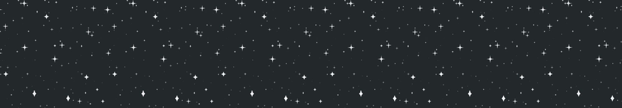

# IBM's Qiskit - Quantum Explorers 2023-2024

## Badge #4: Time Traveler - Quantum Error Correction & Mitigation

- **Story**
- **Instructions**
- **Quiz**
- **Unlock Your Badge**

## Story

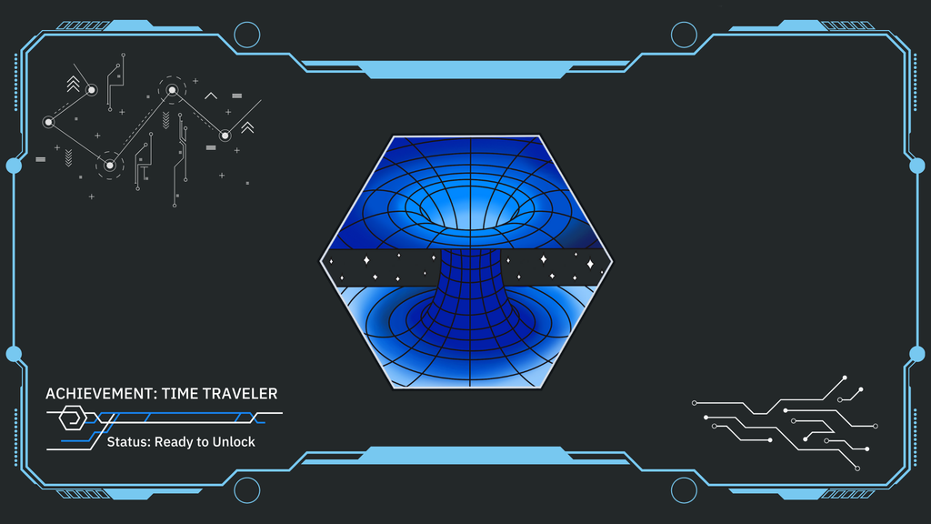

You notice some curious anomalies and apparent glitches aboard your starship. The dessert you saved for later in your private quarters' fridge hasn't been baked yet. According to the ship's Earth history archives, the first moon landing took place in the 18th century. Your cargo is filled with items you were going to collect in two weeks.

Your instruments reveal a noisiness to your timeline, unwanted contributions from neighboring timelines that should have been independent from your own. You suspect it must have been somehow caused by that eerie-looking nebula you passed through not too long ago.

*(Share the curious glitches and anomalies you observe aboard your starship in the* *[#space-exploration channel on Discord!](https://discord.com/channels/979714492533440533/1108653145116131338)** What curious or humorous anomalies have you spotted aboard your starship?)*

Complete this learning module to correct your timeline, and gain the rank of Time Traveler.

## Instructions

The Time Traveler badge is a learning badge, which means this is a learning module.

### Tasks to complete to unlock this achievement

1. Go through the Time Traveler syllabus at your own pace. The syllabus has study materials, labs, exercises, and resources.
   - The **[Time Traveler workbook](https://ibm.box.com/v/qe23-traveler-48)** is a downloadable PDF that includes the syllabus, has interactable checkboxes, and note sections. You can use this to track your progress and take notes.
   - An **[online version of only the syllabus](https://learn.qiskit.org/syllabus/9LN-9LG)** has been created for your convenience as well.
2. Once you think you're ready to unlock the badge, please take the quiz. You may attempt the quiz as many times as you like.

For any questions or discussions about the Time Traveler badge and its material, please use the **[#q-error-cm](https://discord.com/channels/979714492533440533/1095979915964321793)** channel on Discord.

**Important Links**

- **[Time Traveler workbook](https://ibm.box.com/v/qe23-traveler-48)**
- **[Online version of the syllabus](https://learn.qiskit.org/syllabus/9LN-9LG)**
- **[#q-error-cm](https://discord.com/channels/979714492533440533/1095979915964321793)**

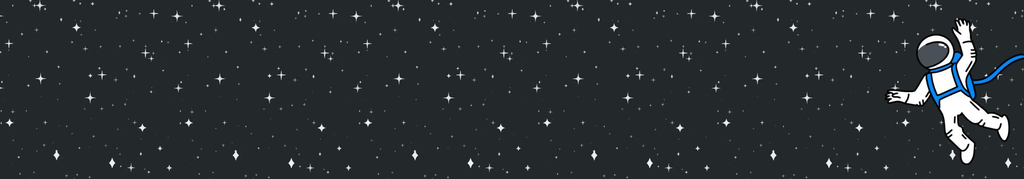

## Quiz

Ready to take the quiz?

For the multiple choice questions, choose the correct answer from the given list. There is only one correct answer. The answer must be a **list with an integer** denoting the option number. If you think all options are wrong, you can just pass an empty list.

For the coding question, please fill in the relevant Qiskit code as instructed.

### Scoring

- Multiple choice questions are worth 1 point each.
- The coding question is worth 3 points.
- Extra credit questions are worth 1 point each
- You must hit 12 points or more to pass.
- You will *not* be informed whether your answer is correct, except for the coding question.

Your score will be revealed at the end in the "Unlock Your Badge" section as a percentage. **Passing score is 80%.** Note: since there are extra credit questions, you may get over 100%!

**Question 1: What is quantum error correction?**

Choose the correct answer from the following list. There is only one correct answer.

1. A technique for improving the speed of quantum computers.
2. A hardware engineering method for reducing and eliminating errors in quantum devices.
3. A technique which involves using multiple qubits or requires huge hardware overhead to detect and eliminate errors.
4. A technique which can be done through probabilistic error cancellation.

The answer must be a **list with an integer** denoting the option number. If you think all options are wrong, you can just pass an empty list.

```python
# build your code here
answer1 = [3]
```

```python
# run this cell to submit your answer

# import the grader for the exercise 1 of the lab/badge 4
from qc_grader.challenges.quantum_explorers23 import grade_badge4_ex1

# expected result type: List
grade_badge4_ex1(answer1)
```

```
Submitting your answer. Please wait...
Thank you for submitting your answer. Your answer has been recorded and, if correct, will count towards your final score.
```

**Question 2: What is quantum error mitigation?**

1. A technique for improving the speed of quantum computers.
2. A hardware engineering method for reducing and eliminating errors in quantum devices.
3. A technique which can involve using a group of circuit outputs to construct results with reduced bias.
4. A technique which involves using multiple qubits or requires huge hardware overhead.

```python
# build your code here
answer2 = [3]
```

```python
# run this cell to submit your answer

# import the grader for the exercise 2 of the lab/badge 4
from qc_grader.challenges.quantum_explorers23 import grade_badge4_ex2

# expected result type: List
grade_badge4_ex2(answer2)
```

```
Submitting your answer. Please wait...
Thank you for submitting your answer. Your answer has been recorded and, if correct, will count towards your final score.
```

**Question 3: What is a difference between quantum error correction and quantum error mitigation?**

1. Quantum error correction focuses on fixing errors in hardware, while quantum error mitigation focuses on producing better algorithm results with current hardware.
2. Quantum error correction is a technique for increasing the speed of quantum computation, while quantum error mitigation is a method for detecting and correcting errors.
3. Quantum error correction is a method for improving the accuracy of quantum measurements, while quantum error mitigation is a technique for increasing the speed of quantum computation.
4. There is no difference between them.

```python
# build your code here
answer3 = [1]
```

```python
# run this cell to submit your answer

# import the grader for the exercise 3 of the lab/badge 4
from qc_grader.challenges.quantum_explorers23 import grade_badge4_ex3

# expected result type: List
grade_badge4_ex3(answer3)
```

```
Submitting your answer. Please wait...
Thank you for submitting your answer. Your answer has been recorded and, if correct, will count towards your final score.
```

**Question 4: Which is not a major source of quantum computing error?**

1. Measurement gate error.
2. Projection noise.
3. Environmental noise.
4. Entanglement noise.

```python
# build your code here
answer4 = [4]
```

```python
# run this cell to submit your answer

# import the grader for the exercise 4 of the lab/badge 4
from qc_grader.challenges.quantum_explorers23 import grade_badge4_ex4

# expected result type: List
grade_badge4_ex4(answer4)
```

```
Submitting your answer. Please wait...
Thank you for submitting your answer. Your answer has been recorded and, if correct, will count towards your final score.
```

**Question 5: When I choose which resilience level to use in my Qiskit Runtime program, which of the following best describes the trade-off decision I must face?**

1. Higher monetary costs vs. time to execute the program.
2. Mitigated error vs. program execution time.
3. Availability of the program’s result metadata vs. method of error mitigation.
4. Method of error mitigation vs. error in the program’s results.

```python
# build your code here
answer5 = [2]
```

```python
# run this cell to submit your answer

# import the grader for the exercise 5 of the lab/badge 4
from qc_grader.challenges.quantum_explorers23 import grade_badge4_ex5

# expected result type: List
grade_badge4_ex5(answer5)
```

```
Submitting your answer. Please wait...
Thank you for submitting your answer. Your answer has been recorded and, if correct, will count towards your final score.
```

**Question 6: Why do we not want to apply the same process of encoding and decoding in classical repetition code to fix errors in quantum computing?**

1. Decoding destroys superposition, an unwanted effect.
2. It’s impossible to copy qubits.
3. We cannot use multiple qubits to represent one logical qubit.
4. False, we can apply the same process to correct quantum computing errors.

```python
# build your code here
answer6 = [2]
```

```python
# run this cell to submit your answer

# import the grader for the exercise 6 of the lab/badge 4
from qc_grader.challenges.quantum_explorers23 import grade_badge4_ex6

# expected result type: List
grade_badge4_ex6(answer6)
```

```
Submitting your answer. Please wait...
Thank you for submitting your answer. Your answer has been recorded and, if correct, will count towards your final score.
```

**Question 7: Which quote does Zlatko Minev mention in his lectures on Noisy Real Hardware?**

1. “Nature isn't classical, dammit, and if you want to make a simulation of nature, you'd better make it quantum mechanical.”
2. “Everyone thought that you couldn't correct errors on quantum computers because as soon as you try to measure a quantum system you disturb it.”
3. “The more success the quantum theory has, the sillier it looks.”
4. “Quantum phenomena do not occur in a Hilbert space, they occur in a laboratory.”

```python
# build your code here
answer7 = [4]
```

```python
# run this cell to submit your answer

# import the grader for the exercise 7 of the lab/badge 4
from qc_grader.challenges.quantum_explorers23 import grade_badge4_ex7

# expected result type: List
grade_badge4_ex7(answer7)
```

```
Submitting your answer. Please wait...
Thank you for submitting your answer. Your answer has been recorded and, if correct, will count towards your final score.
```

**Question 8: Which algorithm is used in the 2022 IBM Quantum Fall Challenge Lab 1 to show how to use Qiskit Runtime for noise mitigation?**

1. Deutsch-Jozsa algorithm.
2. Bernstein-Vazirani algorithm.
3. Shor’s algorithm.
4. Grover’s algorithm.

```python
# build your code here
answer8 = [2]
```

```python
# run this cell to submit your answer

# import the grader for the exercise 8 of the lab/badge 4
from qc_grader.challenges.quantum_explorers23 import grade_badge4_ex8

# expected result type: List
grade_badge4_ex8(answer8)
```

```
Submitting your answer. Please wait...
Thank you for submitting your answer. Your answer has been recorded and, if correct, will count towards your final score.
```

**Question 9: One of the required readings mentioned a theorem that implies that with by using error correction on quantum computers with low physical errors rates in the future, we can reduce the logical error far enough to obtain useful quantum computers. What is the name of that theorem?**

1. Quantum error theorem.
2. Error correction theorem.
3. Threshold theorem.
4. Tolerance theorem.

```python
# build your code here
answer9 = [3]
```

```python
# run this cell to submit your answer

# import the grader for the exercise 9 of the lab/badge 4
from qc_grader.challenges.quantum_explorers23 import grade_badge4_ex9

# expected result type: List
grade_badge4_ex9(answer9)
```

```
Submitting your answer. Please wait...
Thank you for submitting your answer. Your answer has been recorded and, if correct, will count towards your final score.
```

**Question 10: Which of the following best describes the T2 value in a quantum computer?**

1. The time it takes for a qubit to lose its phase.
2. The overall coherence/decoherence time of a qubit.
3. The time it takes for a qubit to “relax” from state 1 to 0.
4. The readout error associated with the measurement gate.

```python
# build your code here
answer10 = [1]
```

```python
# run this cell to submit your answer

# import the grader for the exercise 10 of the lab/badge 4
from qc_grader.challenges.quantum_explorers23 import grade_badge4_ex10

# expected result type: List
grade_badge4_ex10(answer10)
```

```
Submitting your answer. Please wait...
Thank you for submitting your answer. Your answer has been recorded and, if correct, will count towards your final score.
```

**Question 11: I want to run a Qiskit runtime program using the Sampler with M3 error mitigation additionally applied. What should I put in the marked spot in the code fragment as shown in the image?**

1. 1.
2. 2.
3. “m3”.
4. “M3”.

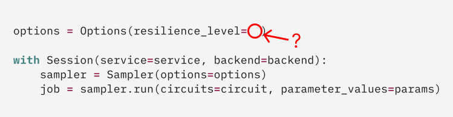

```python
# build your code here
answer11 = [1]
```

```python
# run this cell to submit your answer

# import the grader for the exercise 11 of the lab/badge 4
from qc_grader.challenges.quantum_explorers23 import grade_badge4_ex11

# expected result type: List
grade_badge4_ex11(answer11)
```

```
Submitting your answer. Please wait...
Thank you for submitting your answer. Your answer has been recorded and, if correct, will count towards your final score.
```

**Question 12: Which of the following best describe a main benefit of using Qiskit Runtime for running quantum programs?**

1. Qiskit Runtime enhances the security of quantum computations.
2. Qiskit Runtime simplifies the development of quantum algorithms and programs.
3. Qiskit Runtime enables quantum teleportation between different systems.
4. Qiskit Runtime allows for quantum simulations of very complex physical systems.

```python
# build your code here
answer12 = [2]
```

```python
# run this cell to submit your answer

# import the grader for the exercise 12 of the lab/badge 4
from qc_grader.challenges.quantum_explorers23 import grade_badge4_ex12

# expected result type: List
grade_badge4_ex12(answer12)
```

```
Submitting your answer. Please wait...
Thank you for submitting your answer. Your answer has been recorded and, if correct, will count towards your final score.
```

### Qiskit Code Question

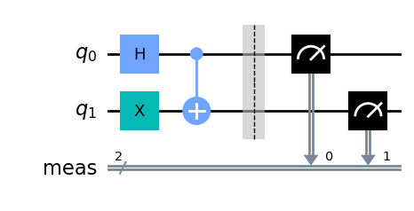

```python
####  do not edit this code      ####
####  you will use this circuit  ####
####  for your code question     ####

# import the quantum circuit
# from the IBM's Qiskit libtrary
from qiskit import QuantumCircuit


# create a quantum circuit with
# a quantum register of two qubits
qc = QuantumCircuit(2)


# apply a Hadamard gate to the 1st
# qubit on the quantum register of
# the quantum circuit before
qc.h(0)

# apply a Pauli-X gate to the 2nd
# qubit on the quantum register of
# the quantum circuit before
qc.x(1)

# apply the CX/CNOT gate on the 1st qubit
# as control and on the 2nd qubit as target,
# both on the quantum register of the quantum circuit
qc.cx(0, 1)


# perform a meausrement of all
# the qubits on the quantum register of
# the Quantum Circuit created before
qc.measure_all()


# draw the Quantum Circuit created before
qc.draw()
```

**Coding Question: Using the Sampler Primitive with a Qiskit Runtime session, run the above circuit twice on a noisy simulator.**

You will first have to create two Options instances; one without where no error mitigation will be applied when using this with the Sampler primitive and Qiskit Runtime, and one with M3 error mitigation.

Then, using a session, run the pre-defined circuit *qc* using the Sampler primitive twice, where the first run uses options with no error mitigation and the second run uses options with M3 error mitigation. When you run the sampler, use **4000 shots**. After the job results are obtained for each, obtain a dictionary containing the quasi-distribution resulting from the circuit.

It may take a short moment for your sampler runs to execute.

**Click to expand for hints.**

- **[Documentation - Help on noisy simulators](https://qiskit.org/documentation/partners/qiskit_ibm_runtime/how_to/noisy_simulators.html#running-a-noisy-simulation)**.
- **[Documentation - Sampler](https://qiskit.org/documentation/partners/qiskit_ibm_runtime/tutorials/how-to-getting-started-with-sampler.html)**.
- **[Documentation - Options](https://qiskit.org/documentation/partners/qiskit_ibm_runtime/stubs/qiskit_ibm_runtime.options.Options.html#options)**.
- **[Documentation - Configuring error mitigation](https://qiskit.org/documentation/partners/qiskit_ibm_runtime/how_to/error-mitigation.html)**.
- **[Documentation - Running primitives in a session](https://qiskit.org/documentation/partners/qiskit_ibm_runtime/how_to/run_session.html)**.
- Use 'sim' to define the simulator options.

```python
# import the Qiskit Runtime Service, Session, Options,
# and Sampler from the Qiksit's IBM Runtime module
from qiskit_ibm_runtime import QiskitRuntimeService,\
                               Session, Options, Sampler

# import the Fake Manila provider from
# the Qiskit's Provider - Fake Provider module
from qiskit.providers.fake_provider import FakeManila

# import the Noise Model from
# the Qiskit's Aer Noise module
from qiskit_aer.noise import NoiseModel


####  save the Qiskit Runtime account              ####
####  credentials if you have not done so already  ####

####  if you need to overwrite the account info,   ####
####  please add the `overwrite=True` option       ####

# perform the instruction call to save
# the Qiskit Runtime account credentials
#QiskitRuntimeService.save_account( channel="ibm_quantum",
#                                   token="my_token", overwrite=True)


# create a Qiskit's Runtime Service object,
# using the IBM Quantum channel
service = QiskitRuntimeService( channel="ibm_quantum" )

# retrieve the IBM's QASM Simulator as the backend service
# note: we will be using the QASM Simulator
backend = service.get_backend( "ibmq_qasm_simulator" )

# print the existing information about
# the IBM's QASM Simulator backend service
print( backend )


# create a Fake Manila backend object
# note: here, from a fake noisy backend,
#       we obtain the noise model, which we will apply to
#       the selected simulator backend from above
fake_backend = FakeManila()

# retrieve the noise model from
# the noisy Fake Manila backend object
noise_model = NoiseModel.from_backend( fake_backend )


# create the quantum simulation object
# note: use this when defining the quantum simulator
#       in your options instances
sim = {

    # define the noise model to use
    # in the quantum simulation
    "noise_model": noise_model,

    # define the seed to use
    # in the quantum simulation
    # note: do not change this value
    #       doing so may result in
    #       your answer being marked
    #       as an incorrect one
    "seed_simulator": 42

}


###########################################################


####### build your code below #########

# create the options for the quantum simulation
# configured with no error mitigation
options = Options(
    simulator=sim,
    resilience_level=0,
)


# create the options for the quantum simulation
# configured with the M3 error mitigation
options_with_m3 = Options(
    simulator=sim,
    resilience_level=1,
)


# within the context of a Session configured
# with the Qiskit's Runtime Service object,
# created before, using the IBM Quantum channel,
# and also using the backend defined before
with Session( service=service, backend=backend ):

    # first, we will run the quntum simulation
    # configured with no error mitigation

    # create the Sampler object with
    # the Session context defined
    # and the relevant options
    sampler = Sampler( options=options )

    # run the Sampler object with
    # a number of shots equal to 4000,
    # retrieving the resulting submitted
    # job for the quantum simulation
    job = sampler.run( qc, shots=4000 )

    # retrieve the count results
    # from the submitted job of
    # the quantum simulation configured
    # with no error mitigation
    results_no_em = job.result()

    # retrieve a dictionary (not a list) of
    # the quasi-distribution probabilities
    # from the count results obtained for
    # the quantum simulation configured
    # with no error mitigation
    quasi_dist_no_em = results_no_em.quasi_dists[0]


    ########################################


    # second, we will run the quantum simulation
    # configured with the M3 error mitigation

    # create the Sampler object with
    # the Session context defined
    # and the relevant options
    sampler = Sampler( options=options_with_m3 )

    # run the Sampler object with
    # a number of shots equal to 4000,
    # retrieving the resulting submitted
    # job for the quantum simulation
    job = sampler.run( qc, shots=4000 )

    # retrieve the count results
    # from the submitted job of
    # the quantum simulation configured
    # with the T-REX error mitigation,
    # as well as with the M3 Sampler
    results_with_m3 = job.result()

    # retrieve a dictionary (not a list) of
    # the quasi-distribution probabilities
    # from the count results obtained for
    # the quantum simulation configured
    # with the T-REX error mitigation,
    # as well as with the M3 Sampler
    quasi_dist_with_m3 = results_with_m3.quasi_dists[0]


####### build your code above #########


###########################################################


# print the quasi-distribution probabilities
# from the count results obtained for
# the quantum simulation configured
# with no error mitigation
print( "Quasi-distribution with No Error Mitigation: ", quasi_dist_no_em )

# print the quasi-distribution probabilities
# from the count results obtained for
# the quantum simulation configured
# with the T-REX error mitigation,
# as well as with the M3 Sampler
print( "Quasi-distribution with Error Mitigation (M3): ", quasi_dist_with_m3 )
```

```
<IBMBackend('ibmq_qasm_simulator')>
Quasi-distribution with No Error Mitigation:  {1: 0.369, 0: 0.13975, 2: 0.45875, 3: 0.0325}
Quasi-distribution with Error Mitigation (M3):  {0: 0.011835180722095105, 1: 0.48784140401270437, 2: 0.4983486948083151, 3: 0.001974720456885419}
```

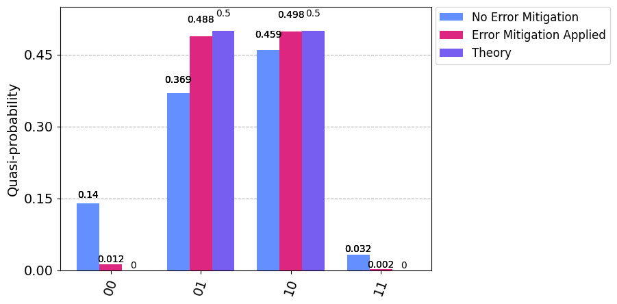

```python
########### cell to visualise your results ###########

# import the statevector object from
# the IBM's Qiskit Quantum Information module
from qiskit.quantum_info import Statevector

# import the plotting histogram function from
# the IBM's Qiskit Visualization module
from qiskit.visualization import plot_histogram


######################################################


#### get the probability distribution results ####

# retrieve the probability distribution
# from the quasi-distribution of
# the results obtained from the execution of
# the quantum circuit created before,
# with no error mitigation applied
binary_prob_dist_no_em = quasi_dist_no_em.binary_probabilities()

# retrieve the probability distribution
# from the quasi-distribution of
# the results obtained from the execution of
# the quantum circuit created before,
# with T-REX error mitigation and M3 sampler applied
binary_prob_dist_with_m3 = quasi_dist_with_m3.binary_probabilities()


######################################################


#### compute the theoretical results ####

# remove all the final measurements on
# all the quantum registers of the quantum circuit
# created before for the quantum simulation
qc.remove_final_measurements()


# retrieve the theoretical measurement probabilities
# from the statevector representing the quantum circuit
# created before, without the measurements applied
theory_probabilities = Statevector(qc).probabilities_dict()

# create a copy of the theoretical measurement probabilities
# from the statevector representing the quantum circuit
# created before, without the measurements applied
theory_probabilities_plot = theory_probabilities.copy()


# create a list with all the possible binary strings
# with 2 bits (i.e., a total of 4 possible different values)
binary_strings_2_bits = [ bin( num )[2:].zfill(2) for num in range( 2**2 ) ]


# for each possible binary string with 2 bits
for binary_string_2_bits in binary_strings_2_bits:

    # if the current binary string with 2 bits is
    # not in the dictionary of the probability
    # distributions from the quasi-distributions of
    # the results obtained from the execution of
    # the quantum circuit created before,
    # using the simulator
    if binary_string_2_bits not in theory_probabilities_plot:

        # add the missing binary string with 2 bits to
        # the dictionary of the probability
        # distributions from the quasi-distributions of
        # the results obtained from the execution of
        # the quantum circuit created before,
        # using the simulator, with a negligible value
        theory_probabilities_plot[ binary_string_2_bits ] = 1e-8


# perform (again) all the final measurements on
# all the quantum registers of the quantum circuit
# created before for the quantum simulation
qc.measure_all()


######################################################


#### plot all the probability distribution results ####

# create the list of the captions for the legend of
# the histogram for the probability distributions
# from the quasi-distributions of the results obtained
# from the execution of the quantum circuit created before,
# without and with error mitigation, as well as
# the theoretically expected results
legends = [ "No Error Mitigation",
            "Error Mitigation Applied", "Theory" ]


# plot the histogram for the probability distributions
# from the quasi-distributions of the results obtained
# from the execution of the quantum circuit created before,
# without and with error mitigation, as well as
# the theoretically expected results
plot_histogram( [ binary_prob_dist_no_em,
                  binary_prob_dist_with_m3,
                  theory_probabilities_plot ], legend=legends )
```

You should obtain a graph that looks like so. The theory legend key has been added into this screenshot for you:

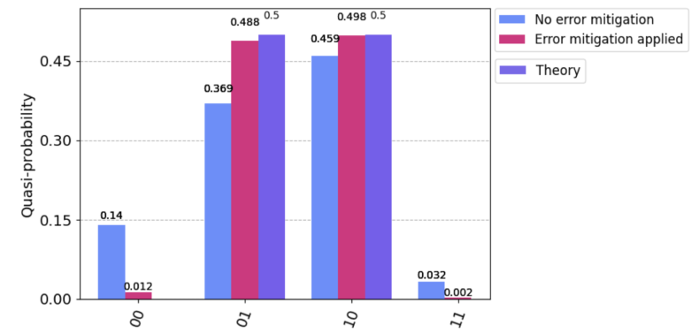

```python
# run this cell to submit your answer

# import the grader for the coding exercise of the lab/badge 4
from qc_grader.challenges.quantum_explorers23 import grade_badge4_code

# expected result type: List
answer_code = grade_badge4_code( [ results_no_em, results_with_m3 ],
                                 [ quasi_dist_no_em, quasi_dist_with_m3 ] )
```

```
Submitting your answer. Please wait...
Congratulations! 🎉 Your answer is correct.
```

#### [Ungraded] Run your circuit on a real device!

Fill in the missing code with your answers from above cells below to run your quantum circuit on a real device. Fill in the missing code with your answers from above.

```python
####  run this cell to run your quantum circuit  ####
####  on a real quantum device                   ####

# retrieve the least-busy backend
# with a minimum number of two qubits
# (this step can take a while)
real_backend = service.least_busy( min_num_qubits=2, simulator=False )

# print the information about the best (i.e., the least-busy)
# backend with a minimum number of two qubits, and an informative
# message about the job submission on this backend
print( "The best backend is " + real_backend.name )
print( "Submitting your job..." )


###########################################################


#######  add your answers from above  #########
#######  before running the cell      #########

# define the options for the quantum simulation
# configured with no error mitigation
options = Options(
    simulator=sim,
    resilience_level=0,
)


# define the options for the quantum simulation
# configured with the M3 error mitigation
options_with_m3 = Options(
    simulator=sim,
    resilience_level=1,
)


# within the context of a Session configured
# with the Qiskit's Runtime Service object,
# created before, using the IBM Quantum channel,
# and also using the backend defined before
with Session( service=service, backend=real_backend ):


    # first, we will run the quantum simulation
    # configured with no error mitigation

    # create the Sampler object with
    # the Session context defined
    # and the relevant options
    sampler = Sampler( options=options )

    # run the Sampler object with
    # a number of shots equal to 4000,
    # retrieving the resulting submitted
    # job for the quantum simulation
    job = sampler.run( qc, shots=4000 )


    # print the ID of the job submitted
    # for the quantum simulation configured
    # with no error mitigation
    # note: do not change this code
    print( f"Job ID: { job.job_id() }" )


    # retrieve the count results
    # from the submitted job of
    # the quantum simulation configured
    # with no error mitigation
    results_no_em = job.result()

    # retrieve a dictionary (not a list) of
    # the quasi-distribution probabilities
    # from the count results obtained for
    # the quantum simulation configured
    # with no error mitigation
    quasi_dist_no_em = results_no_em.quasi_dists[0]


    ###########################################


    # second, we will run the quantum simulation
    # configured with the M3 error mitigation

    # create the Sampler object with
    # the Session context defined
    # and the relevant options
    sampler = Sampler( options=options_with_m3 )

    # run the Sampler object with
    # a number of shots equal to 4000,
    # retrieving the resulting submitted
    # job for the quantum simulation
    job = sampler.run( qc, shots=4000 )


    # print the ID of the job submitted
    # for the quantum simulation configured
    # with the T-REX error mitigation,
    # as well as with the M3 Sampler
    # note: do not change this code
    print( f"Job ID: { job.job_id() }" )


    # retrieve the count results
    # from the submitted job of
    # the quantum simulation configured
    # with the T-REX error mitigation,
    # as well as with the M3 Sampler
    results_with_m3 = job.result()

    # retrieve a dictionary (not a list) of
    # the quasi-distribution probabilities
    # from the count results obtained for
    # the quantum simulation configured
    # with the T-REX error mitigation,
    # as well as with the M3 Sampler
    quasi_dist_with_m3 = results_with_m3.quasi_dists[0]


#######  add your answers from above  #########
#######  before running the cell      #########


###########################################################
```

```
The best backend is ibm_lagos
Submitting your job...
Job ID: ck1fsv2k1qvd8ta3agjg
Job ID: ck1k6qsiifjafcu5oq6g
```

While your jobs are running, you can monitor them! Simply copy the Job ID printed out for you for one of the runs and enter it into the search bar **[here](https://quantum-computing.ibm.com/jobs)**! Make sure you are logged into the IBM Quantum Platform to access this page.

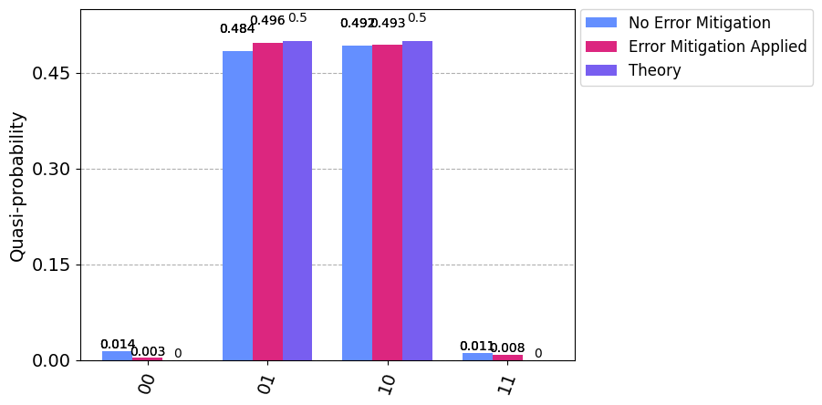

```python
# run this cell to view the output histogram and
# compare the two probability distributions obtained

# retrieve the probability distribution
# from the quasi-distribution of
# the results obtained from the execution of
# the quantum circuit created before,
# with no error mitigation applied,
# but now executed on a real quantum device
binary_prob_dist_no_em = quasi_dist_no_em.binary_probabilities()

# retrieve the probability distribution
# from the quasi-distribution of
# the results obtained from the execution of
# the quantum circuit created before,
# with T-REX error mitigation and M3 sampler applied,
# but now executed on a real quantum device
binary_prob_dist_with_m3 = quasi_dist_with_m3.binary_probabilities()


# create a copy of the probability distribution
# from the quasi-distribution of
# the results obtained from the execution of
# the quantum circuit created before,
# with no error mitigation applied,
# but now executed on a real quantum device
binary_prob_dist_no_em_plot = binary_prob_dist_no_em.copy()

# create a copy of the probability distribution
# from the quasi-distribution of
# the results obtained from the execution of
# the quantum circuit created before,
# with T-REX error mitigation and M3 sampler applied,
# but now executed on a real quantum device
binary_prob_dist_with_m3_plot = binary_prob_dist_with_m3.copy()


# create a list with all the possible binary strings
# with 2 bits (i.e., a total of 4 possible different values)
binary_strings_2_bits = [ bin( num )[2:].zfill(2) for num in range( 2**2 ) ]


# for each possible binary string with 2 bits
for binary_string_2_bits in binary_strings_2_bits:

    # if the current binary string with 2 bits is
    # not in the dictionary of the probability
    # distributions from the quasi-distribution of
    # the results obtained from the execution of
    # the quantum circuit created before,
    # with no error mitigation applied,
    # but now executed on a real quantum device
    if binary_string_2_bits not in binary_prob_dist_no_em_plot:

        # add the missing binary string with 2 bits to
        # the dictionary of the probability
        # distributions from the quasi-distributions of
        # the results obtained from the execution of
        # the quantum circuit created before,
        # using the simulator, with a negligible value
        binary_prob_dist_no_em_plot[ binary_string_2_bits ] = 1e-8

    # if the probability distribution
    # from the quasi-distribution of
    # the results obtained from the execution of
    # the quantum circuit created before,
    # with no error mitigation applied,
    # but now executed on a real quantum device,
    # is lower or equal to 0 (zero)
    elif binary_prob_dist_no_em_plot[ binary_string_2_bits ] <= 0:

        # flip the signal of the probability
        # distribution from the quasi-distributions of
        # the results obtained from the execution of
        # the quantum circuit created before,
        # using the simulator, for a positive value
        binary_prob_dist_no_em_plot[ binary_string_2_bits ] *= -1


# for each possible binary string with 2 bits
for binary_string_2_bits in binary_strings_2_bits:

    # if the current binary string with 2 bits is
    # not in the dictionary of the probability
    # distributions from the quasi-distribution of
    # the results obtained from the execution of
    # the quantum circuit created before,
    # with T-REX error mitigation and M3 sampler applied,
    # but now executed on a real quantum device
    if binary_string_2_bits not in binary_prob_dist_with_m3_plot:

        # add the missing binary string with 2 bits to
        # the dictionary of the probability
        # distributions from the quasi-distributions of
        # the results obtained from the execution of
        # the quantum circuit created before,
        # using the simulator, with a negligible value
        binary_prob_dist_with_m3_plot[ binary_string_2_bits ] = 1e-8

    # if the probability distribution
    # from the quasi-distribution of
    # the results obtained from the execution of
    # the quantum circuit created before,
    # with  T-REX error mitigation and M3 sampler applied,
    # but now executed on a real quantum device,
    # is lower or equal to 0 (zero)
    elif binary_prob_dist_with_m3_plot[ binary_string_2_bits ] <= 0:

        # flip the signal of the probability
        # distribution from the quasi-distributions of
        # the results obtained from the execution of
        # the quantum circuit created before,
        # using the simulator, for a positive value
        binary_prob_dist_with_m3_plot[ binary_string_2_bits ] *= -1


# create the list of the captions for the legend of
# the histogram for the probability distributions
# from the quasi-distributions of the results obtained
# from the execution of the quantum circuit created before,
# without and with error mitigation, as well as
# the theoretically expected results,
# but now executed on a real quantum device
legend = [ "No Error Mitigation",
           "Error Mitigation Applied", "Theory" ]


# plot the histogram for the probability distributions
# from the quasi-distributions of the results obtained
# from the execution of the quantum circuit created before,
# without and with error mitigation, as well as
# the theoretically expected results,
# but now executed on a real quantum device
plot_histogram( [ binary_prob_dist_no_em_plot,
                  binary_prob_dist_with_m3_plot,
                  theory_probabilities_plot ],
                 legend=legend )
```

### Extra Credit Multiple Choice Questions

These questions are more advanced.

**Extra Credit Question A: I want to run a Qiskit runtime program using the Estimator with some error mitigation additionally applied. Which of the following series of resilience level numbers corresponds to this ordering of mitigation techniques: Digital ZNE, T-Rex, PEC, No mitigation.**

1. 1, 2, 3, 4.
2. 0, 2, 3, 4.
3. 2, 1, 3, 0.
4. 0, 2, 1, 3.

```python
# build your code here
answer13 = [3]
```

```python
# run this cell to submit your answer

# import the grader for the exercise 13 of the lab/badge 4
from qc_grader.challenges.quantum_explorers23 import grade_badge4_ex13

# expected result type: List
grade_badge4_ex13(answer13)
```

```
Submitting your answer. Please wait...
Thank you for submitting your answer. Your answer has been recorded and, if correct, will count towards your final score.
```

**Extra Credit Question B: Which of the following statements is false?**

1. T-Rex error mitigation has minimal mitigation costs and it mitigates error associated with readout errors.
2. ZNE typically reduces bias in estimators, but is not guaranteed to produce zero bias.
3. PEC does heavy mitigation with layer sampling.
4. ZNE is theoretically expected to deliver zero bias estimators.

```python
# build your code here
answer14 = [4]
```

```python
# run this cell to submit your answer

# import the grader for the exercise 14 of the lab/badge 4
from qc_grader.challenges.quantum_explorers23 import grade_badge4_ex14

# expected result type: List
grade_badge4_ex14(answer14)
```

```
Submitting your answer. Please wait...
Thank you for submitting your answer. Your answer has been recorded and, if correct, will count towards your final score.
```

**Extra Credit Question C: Which of the following best describes the role of syndrome measurement in quantum error correction?**

1. Syndrome measurement is used to correct errors in the quantum state.
2. Syndrome measurement is used to identify the location of errors in the quantum state.
3. Syndrome measurement is used to optimize the performance of quantum error correction codes.
4. Syndrome measurement is not necessary for quantum error correction.

```python
# build your code here
answer15 = [2]
```

```python
# run this cell to submit your answer

# import the grader for the exercise 15 of the lab/badge 4
from qc_grader.challenges.quantum_explorers23 import grade_badge4_ex15

# expected result type: List
grade_badge4_ex15(answer15)
```

```
Submitting your answer. Please wait...
Thank you for submitting your answer. Your answer has been recorded and, if correct, will count towards your final score.
```

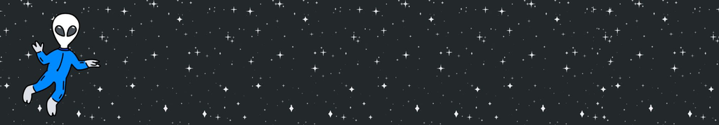

## Unlock Your Badge

Run the cell below to see whether you've passed the quiz. Passing score is 80%. If you have successfully passed, a password will be revealed. (Note: since there are extra credit questions, you may get over 100%!)

Please do not change the code in this cell.

```python
# run this cell to check whether you have passed

# import the grader for the badge 4 of
# the IBM Qiskit's Quantum Explorers 2023-2024
from qc_grader.challenges.quantum_explorers23 import grade_badge4_score

# grade the score of the quiz of the lab for the badge 4
grade_badge4_score("en")
```

```
Submitting your answer. Please wait...

Congratulations, Time Traveler 🎉 🚀! You've passed with a percentage of 113.3%
You've successfully corrected your timeline.'

The password you are looking for is Paradox! inclusive of the !.
```

Have you passed? Congratulations!

Here's what you need to do to unlock your Time Traveler achievement:

1. Download the Time Traveler badge image from **[this link](https://ibm.box.com/s/k8jcwyffda9esj5ch4abr31ytuum8be4)**. The link is password protected; enter the password revealed from the above cell.
2. Post the image to the **[#level-up channel on Discord](https://discord.com/channels/979714492533440533/1096012934829854720)** to get your shiny new Discord label! Please allow up to 5 business days for the badge label to show up under your Discord handle before querying an admin.

Made with ❤ by Rúben André Barreiro (and adapted from IBM Quantum).